# info

```r
library(rpackage)
```

# RPackage for MATH 4573

This r package was created for MATH 4573 by Caleb Guinn. This package contains 4 functions and one dataset.

## Functions

The functions in this package are: -mychisim() a Chi Squared Simulator -myboot() a simple Bootstrapping function -mymlbeta() a maximum likelihood calculator -mycltp() a function that demonstrates the Central Limit Theorem for the Poisson Distribution

### Chi Squared Simulator

You can call the function as it is and the output list will print to console.

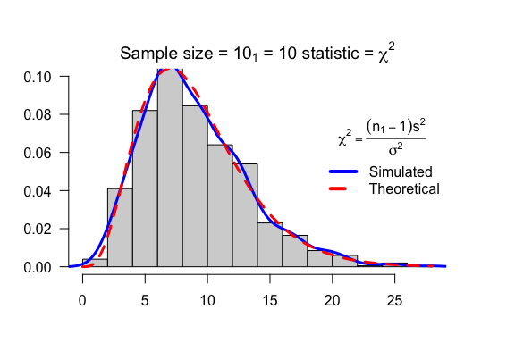

```
#> $w
#>    [1]  6.342699  7.895604  3.142892  4.151759  7.618276  8.794214  7.658412
#>    [8]  7.736656 13.784212  8.185085  8.790999  7.039171 14.079046  9.826702
#>   [15] 10.476667  3.943972  7.014362  5.368127 12.483656  4.777200  6.688474
#>   [22] 13.199085  8.151082  7.464759  5.663430 12.467561  2.529569  4.317207
#>   [29] 10.713606  9.097031 14.111984  9.363905  6.775722  7.994393 13.464959
#>   [36]  6.282722 10.978119 12.427268 10.380682  5.294776  3.419540  6.080447
#>   [43] 16.830417  4.494053 13.795567  8.704764 12.149258  7.240261  8.710994
#>   [50]  8.477397 10.430534  7.074063  6.888441  6.912772  3.523702  7.992660
#>   [57]  3.242577 10.067809  9.251114  6.653148  2.666503  5.941093  5.921679
#>   [64] 14.293766 10.927876  8.194380  9.242813  7.553552 17.006938  4.963900
#>   [71]  9.959083 12.607185 14.375326  9.884838  4.568611  6.521712  8.206351
#>   [78]  6.025860 11.750731 12.131545  7.965610 10.753241  9.406701  1.779433
#>   [85]  2.169507  6.552754 10.618453  4.695530  6.107872  2.678234 11.634436
#>   [92]  5.445592  7.503390  8.268424 12.222390  7.298423  3.853080  6.269361
```

[output cut: 139 more lines]

```r
mychisim(n=10,sigma=4,mean=10,iter=1000,ymax=0.1)
```

Or you can assign the function to an object and the object will contain the list instead, the plot will still be shown.

```r
c<-mychisim(n=10,sigma=4,mean=10,iter=1000,ymax=0.1)
```

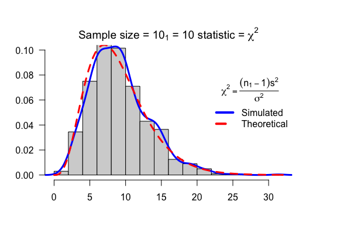

### Bootstrapping Function

The function creates a bootstrapped sample from the initial sample x. The statistic for the function as well as the type of distribution can be changed to produce different outputs.

#### Example 1

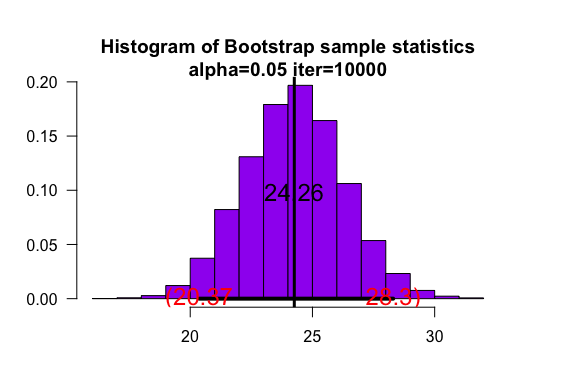

```
#> $ci
#>     2.5%    97.5%
#> 20.36697 28.30322
#>
#> $fun
#> [1] "mean"
#>
#> $x
#>  [1] 29.77739 29.96183 16.40416 16.70940 21.78427 11.96230 10.78513 42.44915
#>  [9] 22.11721 11.91134 24.30548 12.75073 33.08996 20.07850 29.52694 34.99633
#> [17] 29.67030 28.76052 42.03491 14.64538 38.28122 19.05713 41.11285 13.87326
#> [25] 10.39817
#>
#> $para
#> $breaks
#>  [1] 16 17 18 19 20 21 22 23 24 25 26 27 28 29 30 31 32
#>
#> $counts
#>  [1]    1    8   28  121  373  822 1309 1791 1968 1643 1062  536  232   76   23
#> [16]    7
#>
#> $density
#>  [1] 0.0001 0.0008 0.0028 0.0121 0.0373 0.0822 0.1309 0.1791 0.1968 0.1643
#> [11] 0.1062 0.0536 0.0232 0.0076 0.0023 0.0007
#>
#> $mids
#>  [1] 16.5 17.5 18.5 19.5 20.5 21.5 22.5 23.5 24.5 25.5 26.5 27.5 28.5 29.5 30.5
#> [16] 31.5
#>
#> $xname
#> [1] "xstat"
#>
#> $equidist
#> [1] TRUE
#>
#> attr(,"class")
#> [1] "histogram"
```

```r
set.seed(40)
sam<-rnorm(25,mean=25,sd=10)
myboot(x=sam,fun="mean",iter=10000, xlab="mean",col="Purple")
```

#### Example 2

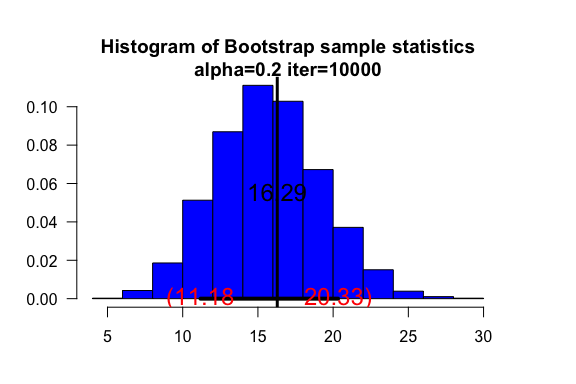

```
#> $ci
#>      10%      90%
#> 11.18218 20.32860
#>
#> $fun
#> [1] "var"
#>
#> $x
#>  [1]  6.4265012  6.5077401  1.8958495  5.3836641  1.4179366  0.7925928
#>  [7]  8.0380097 14.7293204  5.2917468  2.7989621  7.9632983  2.8733832
#> [13]  7.4419824  2.2828464  5.9877646 12.9354365  1.4996069  1.7478044
#> [19] 12.3674161  8.4093535 10.2053201  8.0243948  6.5178039  7.9118846
#> [25]  1.6924333 10.7938057  5.7341134 15.1533278  3.8545321  8.1861897
#>
#> $para
#> $breaks
#>  [1]  4  6  8 10 12 14 16 18 20 22 24 26 28 30
#>
#> $counts
#>  [1]    5   85  372 1026 1739 2223 2057 1345  743  301   78   21    5
#>
#> $density
#>  [1] 0.00025 0.00425 0.01860 0.05130 0.08695 0.11115 0.10285 0.06725 0.03715
#> [10] 0.01505 0.00390 0.00105 0.00025
#>
#> $mids
#>  [1]  5  7  9 11 13 15 17 19 21 23 25 27 29
#>
#> $xname
#> [1] "xstat"
#>
#> $equidist
#> [1] TRUE
#>
#> attr(,"class")
#> [1] "histogram"
```

```r
set.seed(40)
sam<-rgamma(30,shape=2,scale=3)
myboot(x=sam,fun="var",iter=10000,xlab="variance", col="Blue",alpha=0.20)
```

#### Example 3

You can also put the function output list to an object so that only the plot is shown:

```r
set.seed(40)
sam<-rbeta(30,shape1=2,shape2=3)
b<-myboot(x=sam,fun="median",iter=10000,xlab="median", col="Yellow",alpha=0.20)
```

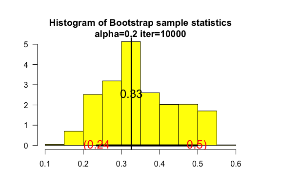

### Maximum Likelihood Estimator for Beta Distribution

Creates a MLE for the randomly generated beta distribution.

#### Example 1

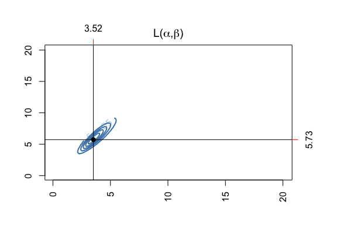

```
#> $x
#>  [1] 0.5711568 0.4288236 0.6303780 0.4197403 0.2907304 0.4008445 0.4879064
#>  [8] 0.5098774 0.2205372 0.2059636 0.6303780 0.2938868 0.5711568 0.6303780
#> [15] 0.2969759 0.4288236 0.2113029 0.4008445 0.2969759 0.2907304 0.1339279
#> [22] 0.5718715 0.4288236 0.2059636 0.1257969 0.2349959 0.2907304 0.2969759
#> [29] 0.2205372 0.5718715
#>
#> $coord
#>      row col
#> [1,]  18  29
#>
#> $maxl
#> [1] 2959690
#>
#> $maxalpha
#> [1] 3.517172
#>
#> $maxbeta
#> [1] 5.728283
```

```r
sam<-rbeta(30,shape1=3,shape2=4)
nsam<-length(sam)
mymlbeta(x=sample(sam,nsam,replace=TRUE),alpha=seq(0.1,20,length=100),beta=seq(0.1,20,length=100),lwd=2,labcex=1,col="steelblue")
```

#### Example 2

```r
sam<-rbeta(50,shape1=3,shape2=4)
nsam<-length(sam)
m<-mymlbeta(x=sample(sam,nsam,replace=TRUE),alpha=seq(0.1,20,length=100),
beta=seq(0.1,20,length=100),lwd=2,labcex=1,col="red")
```

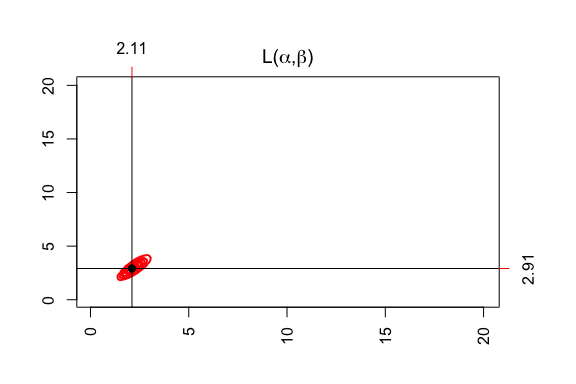

### Central Limit Theorem for Poisson Distribution

Creates a density histogram of the sample mean for the poisson distribution generated, a frequency barplot of the sampled y, and a probability plot for the function.

#### Example 1

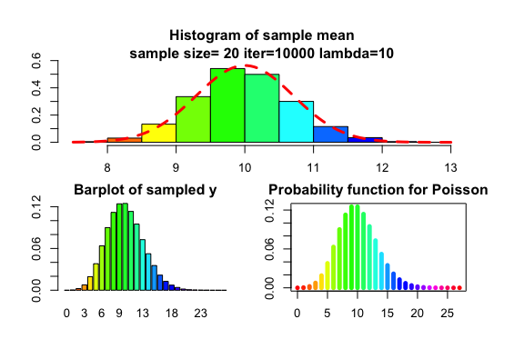

```r
mycltp(n=20,iter=10000,lambda=10)
```

#### Example 2

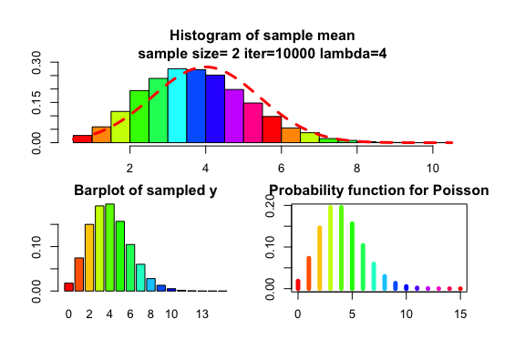

```r
mycltp(n=2,iter=10000,lambda=4)
```

#### Example 3

```r
p<-mycltp(n=5,iter=10000,lambda=10)
```

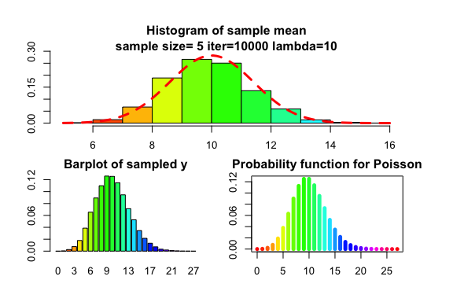

#### Example 4

```r
p<-mycltp(n=5,iter=10000,lambda=4)
```

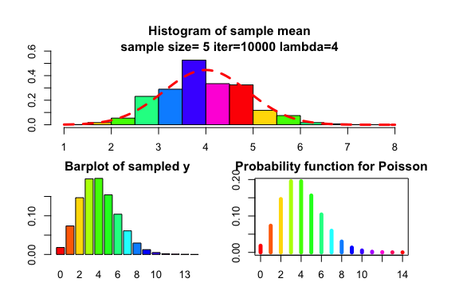

## Data

```r
head(POWERLOADS)
```

```
#> # A tibble: 6 × 2
#>    TEMP  LOAD
#>   <dbl> <dbl>
#> 1    94 136
#> 2    96 132.
#> 3    95 141.
#> 4   108 189.
#> 5    67  96.5
#> 6    88 116.
```